# Series de tiempo

## Comparación de modelos

Usualmente, los parámetros referentes a un modelo GARCH varían entre 1 y 2. De tal manera, probaremos con los siguientes modelos:

```r
Gmod2 <- garchFit(formula = ~ garch(2,1), data = logs,
                  # Utilizamos como distribucion condicional la t de student
                  cond.dist="std", trace=FALSE)
summary(Gmod2)
```

```
##
## Title:
##  GARCH Modelling
##
## Call:
##  garchFit(formula = ~garch(2, 1), data = logs, cond.dist = "std",
##     trace = FALSE)
##
## Mean and Variance Equation:
##  data ~ garch(2, 1)
## <environment: 0x0000000029669918>
##  [data = logs]
##
## Conditional Distribution:
##  std
##
## Coefficient(s):
##         mu       omega      alpha1      alpha2       beta1       shape
## 6.2062e-04  4.5501e-06  1.0582e-01  1.0000e-08  8.9363e-01  7.6001e+00
##
## Std. Errors:
##  based on Hessian
##
## Error Analysis:
##         Estimate  Std. Error  t value Pr(>|t|)
## mu     6.206e-04   7.922e-04    0.783  0.43338
## omega  4.550e-06   5.471e-06    0.832  0.40557
## alpha1 1.058e-01   9.061e-02    1.168  0.24286
## alpha2 1.000e-08   1.170e-01    0.000  1.00000
## beta1  8.936e-01   6.249e-02   14.299  < 2e-16 ***
## shape  7.600e+00   2.699e+00    2.816  0.00486 **
## ---
## Signif. codes:  0 '***' 0.001 '**' 0.01 '*' 0.05 '.' 0.1 ' ' 1
##
## Log Likelihood:
##  969    normalized:  2.6
##
## Description:
##  Fri Feb 10 09:07:36 2023 by user: usuario
##
##
## Standardised Residuals Tests:
##                                 Statistic p-Value
##  Jarque-Bera Test   R    Chi^2  25        3.9e-06
##  Shapiro-Wilk Test  R    W      0.99      0.0012
##  Ljung-Box Test     R    Q(10)  7.7       0.66
##  Ljung-Box Test     R    Q(15)  10        0.79
##  Ljung-Box Test     R    Q(20)  14        0.82
##  Ljung-Box Test     R^2  Q(10)  3.9       0.95
##  Ljung-Box Test     R^2  Q(15)  5.9       0.98
##  Ljung-Box Test     R^2  Q(20)  20        0.48
##  LM Arch Test       R    TR^2   4.1       0.98
##
## Information Criterion Statistics:
##  AIC  BIC  SIC HQIC
## -5.2 -5.1 -5.2 -5.1
```

```r
Gmod3 <- garchFit(formula = ~ garch(2,2), data = logs, cond.dist="std", trace=FALSE)
summary(Gmod3)
```

```
##
## Title:
##  GARCH Modelling
##
## Call:
##  garchFit(formula = ~garch(2, 2), data = logs, cond.dist = "std",
##     trace = FALSE)
##
## Mean and Variance Equation:
##  data ~ garch(2, 2)
## <environment: 0x00000000279653b8>
##  [data = logs]
##
## Conditional Distribution:
##  std
##
## Coefficient(s):
##         mu       omega      alpha1      alpha2       beta1       beta2
## 6.3263e-04  5.3058e-06  1.2990e-01  1.0000e-08  6.3619e-01  2.3425e-01
##      shape
## 7.5979e+00
##
## Std. Errors:
##  based on Hessian
##
## Error Analysis:
##         Estimate  Std. Error  t value Pr(>|t|)
## mu     6.326e-04   7.917e-04    0.799  0.42426
## omega  5.306e-06         NaN      NaN      NaN
## alpha1 1.299e-01   7.530e-02    1.725  0.08452 .
## alpha2 1.000e-08         NaN      NaN      NaN
## beta1  6.362e-01         NaN      NaN      NaN
## beta2  2.342e-01         NaN      NaN      NaN
## shape  7.598e+00   2.687e+00    2.828  0.00469 **
## ---
## Signif. codes:  0 '***' 0.001 '**' 0.01 '*' 0.05 '.' 0.1 ' ' 1
##
## Log Likelihood:
##  969    normalized:  2.6
##
## Description:
##  Fri Feb 10 09:07:37 2023 by user: usuario
##
##
## Standardised Residuals Tests:
##                                 Statistic p-Value
##  Jarque-Bera Test   R    Chi^2  25        3e-06
##  Shapiro-Wilk Test  R    W      0.99      0.001
##  Ljung-Box Test     R    Q(10)  7.6       0.67
##  Ljung-Box Test     R    Q(15)  10        0.81
##  Ljung-Box Test     R    Q(20)  14        0.82
##  Ljung-Box Test     R^2  Q(10)  3.6       0.96
##  Ljung-Box Test     R^2  Q(15)  5.5       0.99
##  Ljung-Box Test     R^2  Q(20)  20        0.48
##  LM Arch Test       R    TR^2   3.8       0.99
##
## Information Criterion Statistics:
##  AIC  BIC  SIC HQIC
## -5.2 -5.1 -5.2 -5.1
```

```r
Gmod4 <- garchFit(formula = ~ garch(1,2), data = logs, cond.dist="std", trace=FALSE)
summary(Gmod4)
```

```
##
## Title:
##  GARCH Modelling
##
## Call:
##  garchFit(formula = ~garch(1, 2), data = logs, cond.dist = "std",
##     trace = FALSE)
##
## Mean and Variance Equation:
##  data ~ garch(1, 2)
## <environment: 0x0000000029c49840>
##  [data = logs]
##
## Conditional Distribution:
##  std
##
## Coefficient(s):
##         mu       omega      alpha1       beta1       beta2       shape
## 6.3263e-04  5.3059e-06  1.2990e-01  6.3619e-01  2.3425e-01  7.5979e+00
##
## Std. Errors:
##  based on Hessian
##
## Error Analysis:
##         Estimate  Std. Error  t value Pr(>|t|)
## mu     6.326e-04   7.918e-04    0.799  0.42430
## omega  5.306e-06   5.504e-06    0.964  0.33508
## alpha1 1.299e-01   7.563e-02    1.718  0.08587 .
## beta1  6.362e-01   6.048e-01    1.052  0.29282
## beta2  2.342e-01   5.551e-01    0.422  0.67301
## shape  7.598e+00   2.690e+00    2.824  0.00474 **
## ---
## Signif. codes:  0 '***' 0.001 '**' 0.01 '*' 0.05 '.' 0.1 ' ' 1
##
## Log Likelihood:
##  969    normalized:  2.6
##
## Description:
##  Fri Feb 10 09:07:37 2023 by user: usuario
##
##
## Standardised Residuals Tests:
##                                 Statistic p-Value
##  Jarque-Bera Test   R    Chi^2  25        3e-06
##  Shapiro-Wilk Test  R    W      0.99      0.001
##  Ljung-Box Test     R    Q(10)  7.6       0.67
##  Ljung-Box Test     R    Q(15)  10        0.81
##  Ljung-Box Test     R    Q(20)  14        0.82
##  Ljung-Box Test     R^2  Q(10)  3.6       0.96
##  Ljung-Box Test     R^2  Q(15)  5.5       0.99
##  Ljung-Box Test     R^2  Q(20)  20        0.48
##  LM Arch Test       R    TR^2   3.8       0.99
##
## Information Criterion Statistics:
##  AIC  BIC  SIC HQIC
## -5.2 -5.1 -5.2 -5.1
```

Los valores de los criterios de información parecen no variar mucho, o nada. De tal manera, elegir cualquiera de ellos es apropiado.

Por ejemplo, utilizando el modelo `Gmod2` podemos ver las predicciones

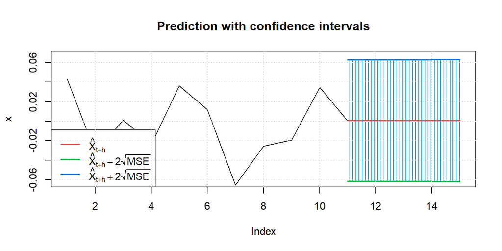

```
##   meanForecast meanError standardDeviation lowerInterval upperInterval
## 1      0.00062     0.031             0.031        -0.061         0.063
## 2      0.00062     0.031             0.031        -0.062         0.063
## 3      0.00062     0.031             0.031        -0.062         0.063
## 4      0.00062     0.031             0.031        -0.062         0.063
## 5      0.00062     0.031             0.031        -0.062         0.063
```

```r
predict(Gmod2, n.ahead = 5, plot=TRUE, nx=10)
```

notamos que los intervalos de predicción son del -6% al 6%, y donde el promedio de la predicción es de 0.062 %, que representa un diferencia pequeña respecto al primer modelo GARCH ajustado.